# Data Exploration: Cooperation

Adams

September 16, 2021

|  | player | score |
| --- | --- | --- |
| 1 | foolMeOnce | 1560 |

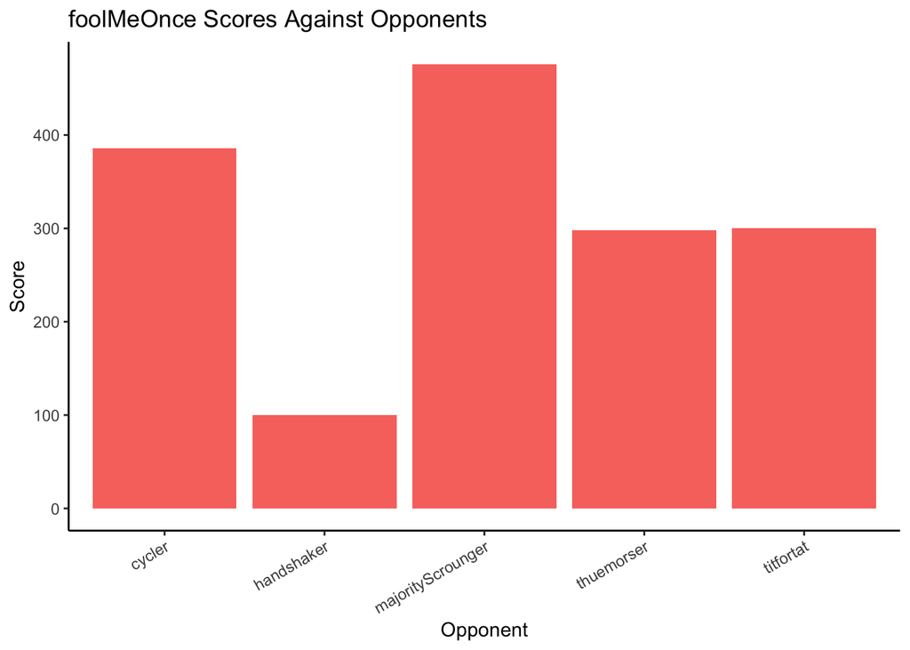

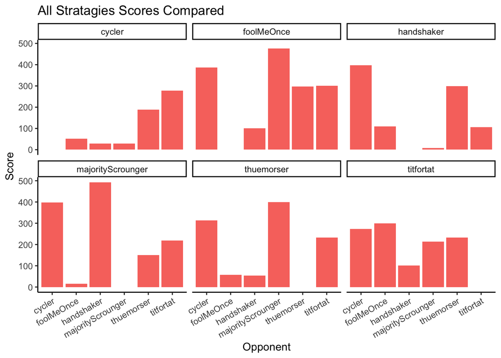

## Question 4

**What is the main difference between the game you played here and the tournament Axelrod implemented? How do you think this difference might matter?**

In class we created and ran a small simulation tournament of different cooperation strategies under the framework of the ‘prisoner’s dilemma’ in a similar fashion to the work of Axelrod. We selected six different strategies and then, following Axelrod’s same method, played the different strategies against each other and recorded the scores. For simplicity they are referred to as ‘player’ and ‘opponent’, even though the scenario compares cooperation and defection. I did not read the strategies of the six players I chose before picking, instead I took a slightly more randomized approach in selecting the names I thought were the most interesting (the very scientific method of picking the cool names) and so was not aware how they would operate (except for titfortat, which Axelrod explained in detail).

| player | score |
| --- | --- |
| foolMeOnce | 1560 |
| majorityScrounger | 1274 |
| titfortat | 1120 |
| thuemorser | 1058 |
| handshaker | 920 |
| cycler | 573 |

| winner | n() |
| --- | --- |
| handshaker | 4 |
| foolMeOnce | 3 |
| majorityScrounger | 3 |
| thuemorser | 2 |
| tie | 2 |
| cycler | 1 |

After running all of the six strategies against each other in a round-robin, it was clear that the results weren’t entirely consistent with the findings of Axelrod. The most obvious difference is that Axelrod’s winning strategy, titfortat, didn’t win. In total points titfortat came third and failed to score a single victory. However this result can be explained in the differences in how my tournament was set up compared to Axelrod’s original. By having only six competing strategies, there is less chance for balance in how the strategies compare to others. For example if five were heavy defectors then the one strategy that favored cooperation would lose out, even if under different circumstances with a different six the same strategy would come out as the winner. The evolutionary stable strategy can’t prevail as the population of different strategies isn’t large enough for it to come out on top. The scores produced form my tournament help explain this as they show a lack of consistency:

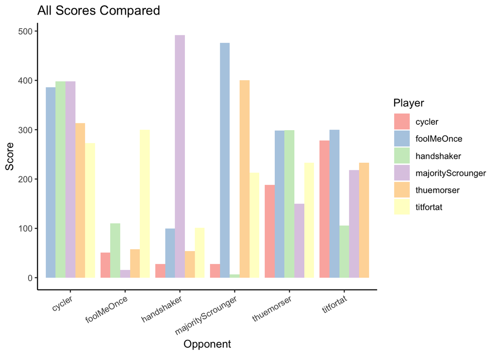

At an individual level it is always more advantageous to defect which is why with a smaller sample the winning strategy has defective rules, but as we have seen when played enough times against enough different strategies the cooperating strategy that sanctions/defects wins out eventually - being nice is advantageous. This is why Axelrod found titfortat to be the winner each time. Even though it didn’t win in this smaller scale round-robin, the consistently that scored the overall win in a larger tournament is evident even here. titfortat will rack up the points with a high average even if it doesn’t always win. This can be seen by its score standard deviation compared to that of the other five strategies I chose to look at.

| player | numeric.sd |
| --- | --- |
| titfortat | 76.66159 |
| cycler | 113.06105 |
| foolMeOnce | 139.33413 |
| thuemorser | 153.83855 |
| handshaker | 159.61673 |
| majorityScrounger | 191.13660 |

The consistency that titfortat shows is what allows it to be the winning strategy over many iterations of the prisoners dilemma. The principles of Axelrod’s conclusions can be seen even if the results were not the same.